# Gráficos

Sebastian Landeo

2024-06-28

## Gráficos con la función `plot`

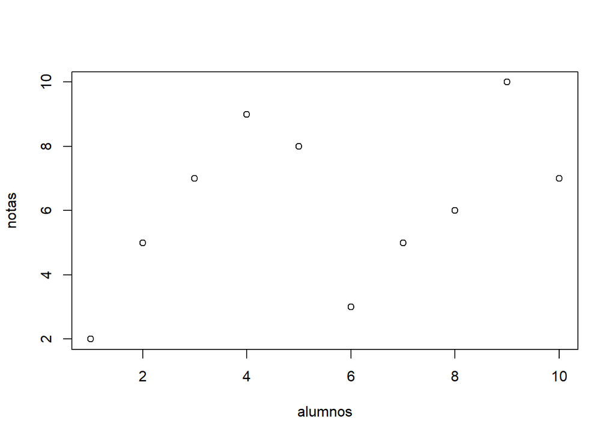

```r
alumnos = c(1:10)
notas = c(2,5,7,9,8,3,5,6,10,7)
plot(alumnos, notas)
```

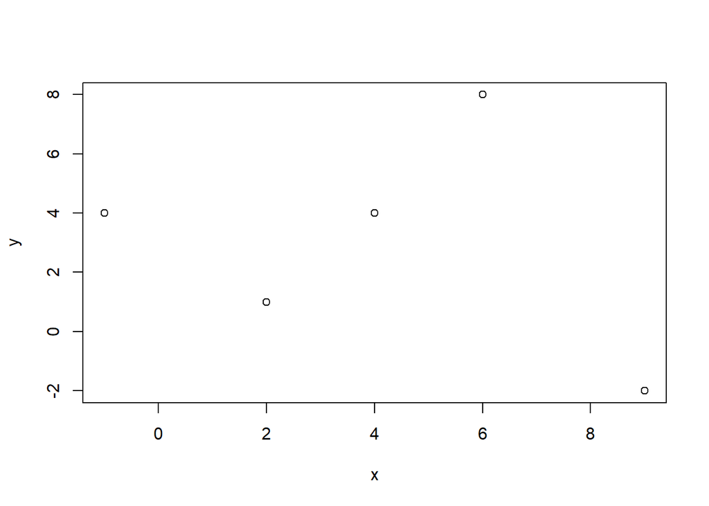

Gráfico básico explicando el uso del plot

```r
x= c(2, 6, 4, 9, -1)
y = c(1, 8, 4, -2, 4)
plot(x,y)
```

`plot(1:n, x)`

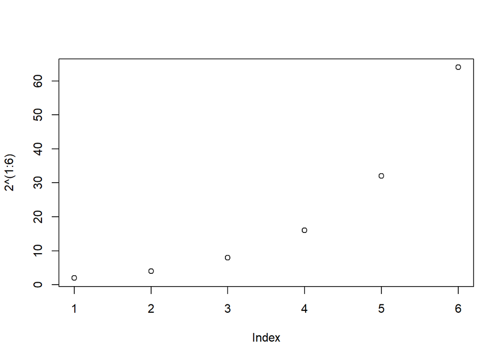

```r
plot(2^(1:6))
```

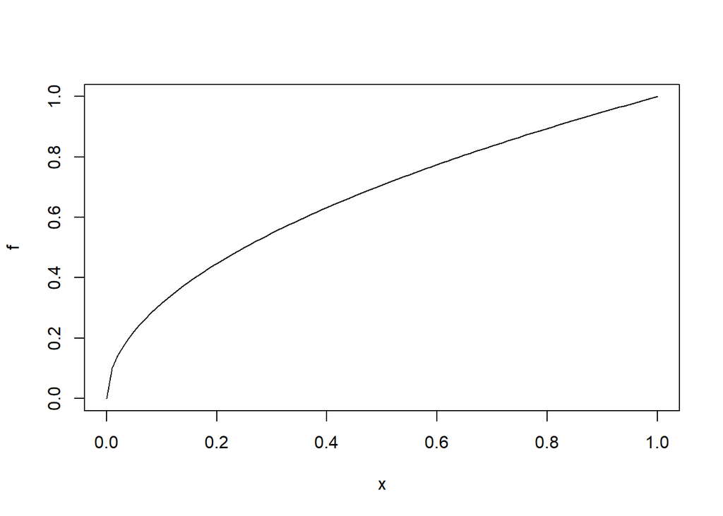

```r
f <- function(x){sqrt(x)}
plot(f)
```

Parámetros de la función plot()  
log: para indicar que queremos el gráfico en escala algorítmica  
main(“título”): para poner el título al gráfico. Si en vez de un texto queráis poner una expresión matemática, téneis que ultilizar la función expression()  
xlab(“etiqueta”): para poner etiqueta al eje x  
ylab(“etiqueta”): para poner etiqueta al eje y  
pch=n: para elegir el símbolo de los puntos n = 0,1,…,25. El valor por defecto es pch = 1  
cex: para elegir el tamaño de símbolos  
col=“color en ingles” : para elgir el color de los símbolos. Gamas de colores.

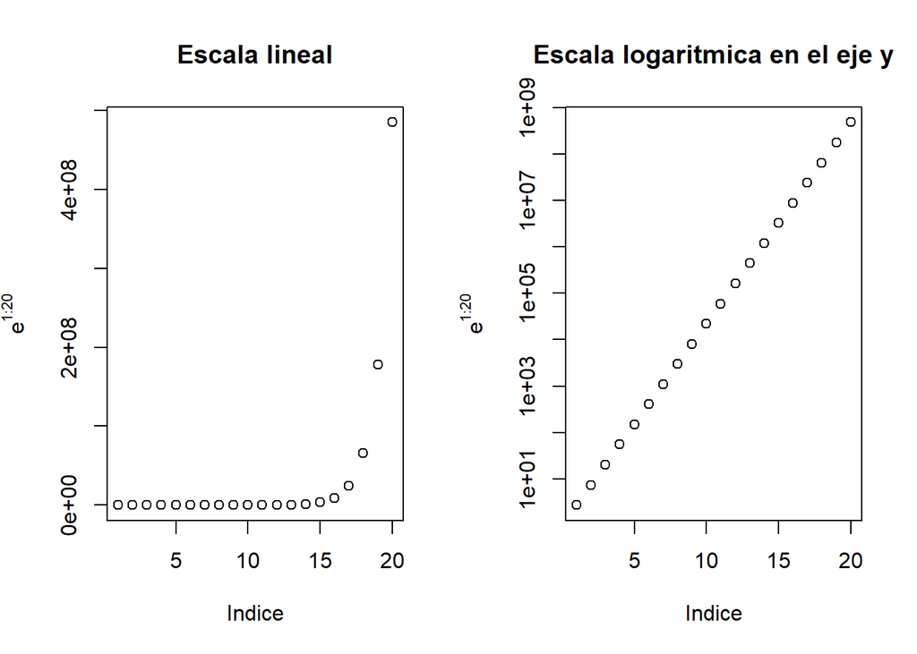

[output not shown]

[figure not shown]

```r
par(mfrow = c(1,2))
plot = plot(exp(1:20), xlab = "Indice", ylab = expression(e^{1:20}), main = "Escala lineal")
plotLog = plot(exp(1:20), log="y", xlab = "Indice", ylab = expression(e^{1:20}), main = "Escala logaritmica en el eje y")
```

Parámetro de la función plot()  
type: para elegir el tipo de gráfico que queremos:  
- p: puntos(valor por defecto)  
- l: líneas rectas que unen los puntos (dichos puntos no tienen símbolo)  
- b: líneas rectas que unen los puntos (dichos puntos tinen símbolo). Las líneas no traspasan los puntos.  
- o: como el anterior pero en este caso las líneas si que traspasan los puntos  
- h: histograma de líneas  
- s: histograma de escalones  
- n: para no dibujar los puntos

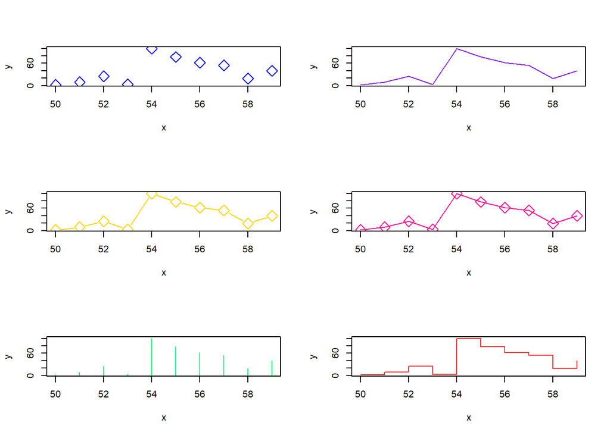

```r
par(mfrow = c(3,2))
x = c(50:59)
y = c(2,9,25,3,100,77,62,54,19,40)
plot(x,y, pch=23, cex=2, col = "blue", type = "p")
plot(x,y, pch=23, cex=2, col = "blueviolet", type = "l")
plot(x,y, pch=23, cex=2, col = "gold", type = "b")
plot(x,y, pch=23, cex=2, col = "deeppink", type = "o")
plot(x,y, pch=23, cex=2, col = "springgreen", type = "h")
plot(x,y, pch=23, cex=2, col = "firebrick1", type = "s")
```

```r
par(mfrow = c(1,1))
```

lty: para especificar el tipo de línea  
- “solid”: 1: línea continua (valor por defecto)  
- “dashed”: 2: línea discontinua  
- “dotted”: 3: línea de puntos  
- “dotdashed”: 4: línea que alterna puntos y rayas  
lwd: para especificar el grosor de las líneas  
xlim: para modificar el rango del eje X  
ylim: para modificar el rango del eje Y  
xaxp: para modificar posiciones de las marcas en el eje X  
yaxp: para modificar posiciones de las marcas en el eje Y

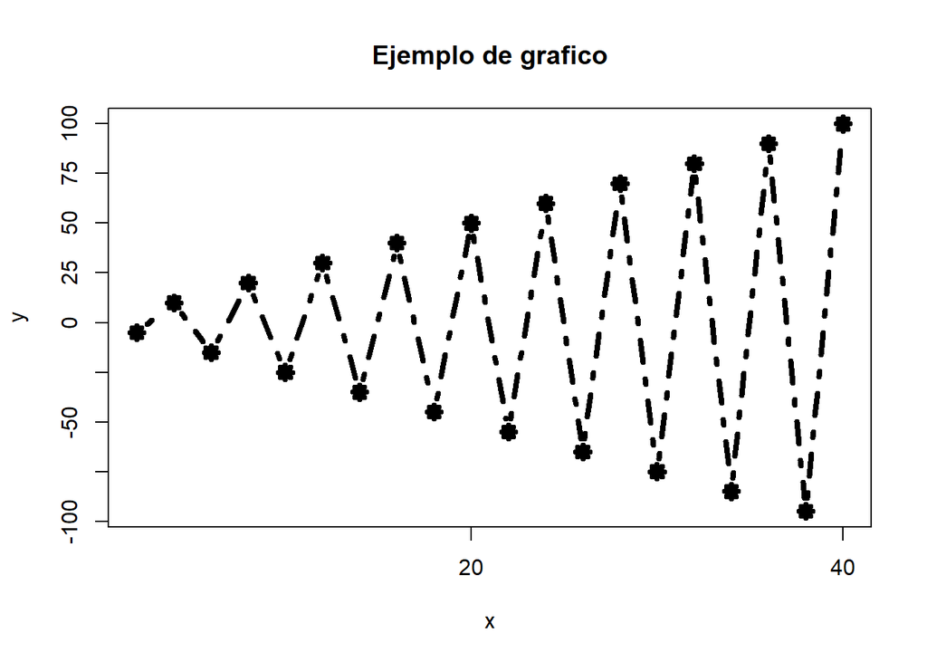

```r
x = (2*(1:20))
y = (-1)^(1:20)*5*(1:20)
plot(x, y, main = "Ejemplo de grafico", pch = 8, cex = 1, type = "b", lty = 4, lwd = 4, xaxp = c(0,40,2), yaxp = c(-100,100,8))
```

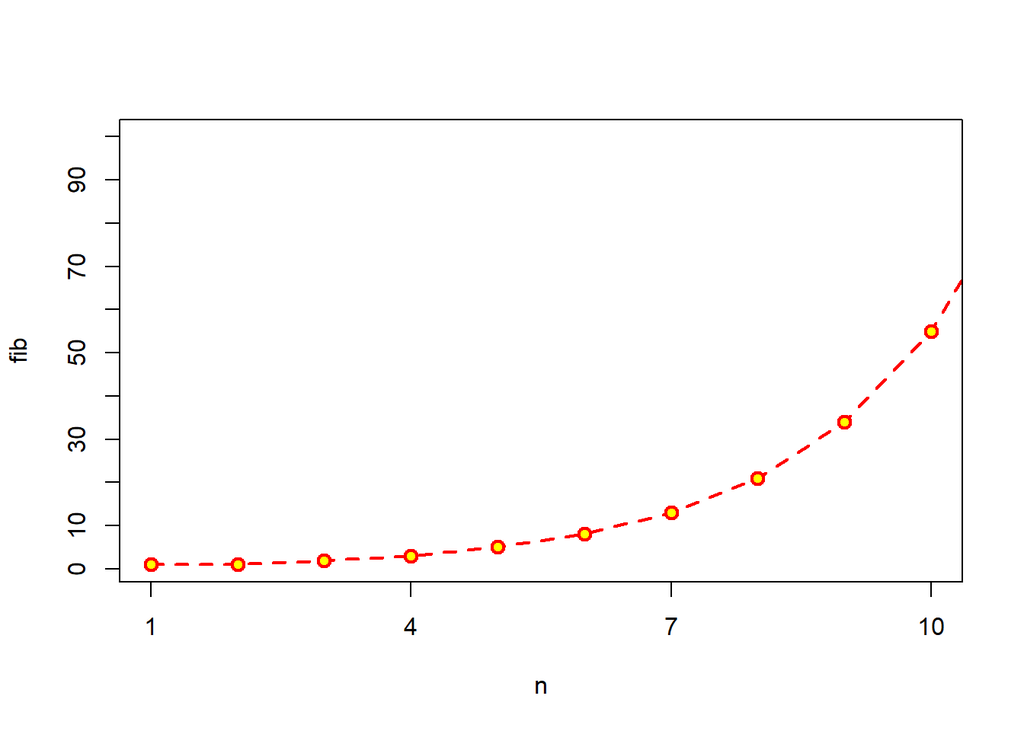

```r
plot(n, fib, pch = 21, col = "red", bg = "yellow", cex = 1.2, type = "o", lty = "dashed", lwd = 2, xlim = c(1,10), ylim = c(1,100), xaxp = c(1,10,3), yaxp = c(0,100,10))
```

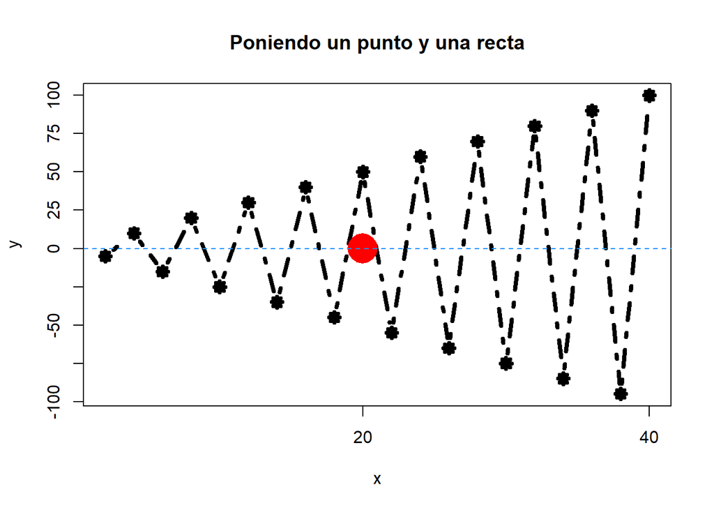

```r
x = (2*(1:20))
y = (-1)^(1:20)*5*(1:20)
plot(x, y, main = "Poniendo un punto y una recta", pch = 8, cex = 1, type = "b", lty = 4, lwd = 4, xaxp = c(0,40,2), yaxp = c(-100,100,8))
points(20, 0, col ="red", cex = 4, pch =16)
abline(h=0, lty=2, col = "dodgerblue")
```

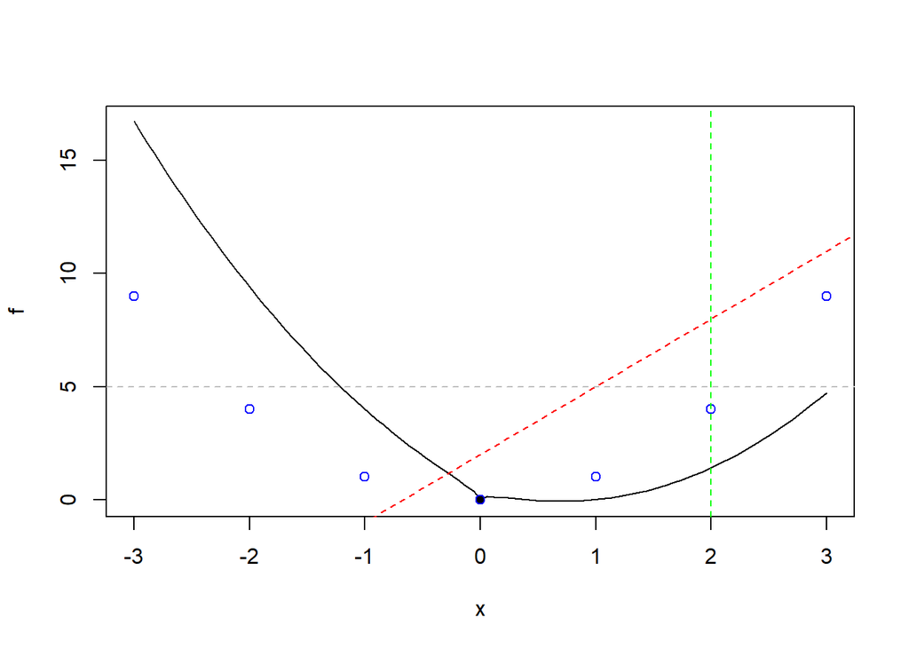

```r
f <- function(x){
  x^2 - 2*x + sqrt(abs(x))
}
plot(f, xlim = c(-3,3))
points(0,0, pch = 19)
points(-3:3, (-3:3)^2, col = "blue")
abline(2,3, lty = "dashed", col = "red")
abline(v = 2, lty = "dashed", col = "green")
abline(h = 5, lty = "dashed", col = "gray")
```

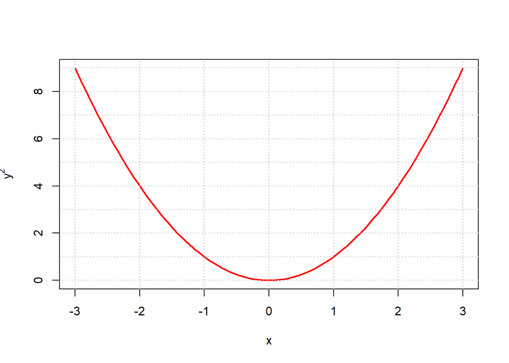

```r
f <- function(x){x^2}
plot(f, xlim = c(-3,3), col = "red", lwd = 2, ylab = expression(y^2), xlab = "x")
abline(h=0:9, v=-3:3, lty="dotted", col="grey")
```

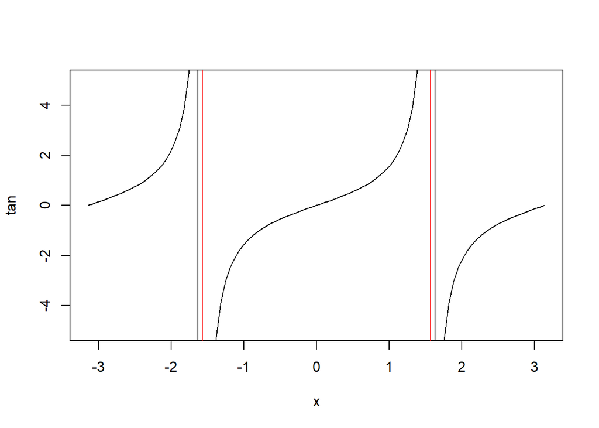

```r
plot(tan, xlim = c(-pi, pi), ylim = c(-5,5))
abline(v = c(-pi/2, pi/2), col = "red")
```

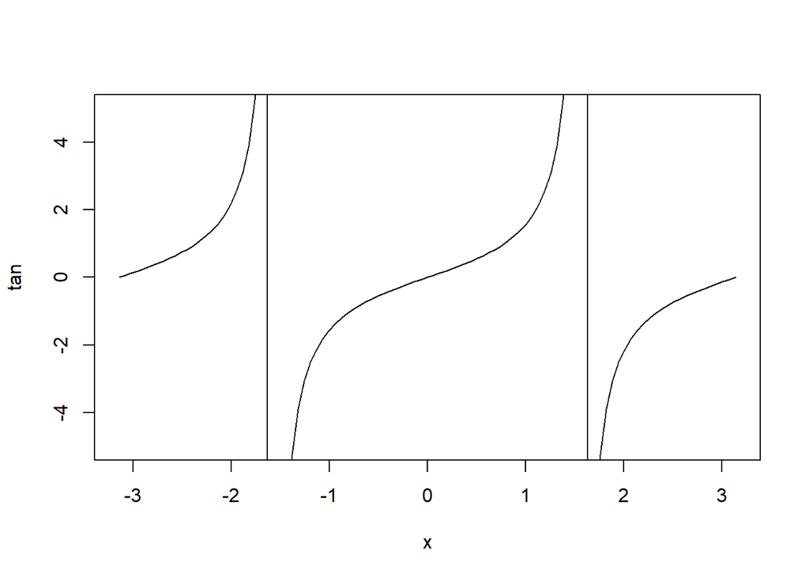

```r
plot(tan, xlim = c(-pi, pi), ylim = c(-5, 5))
```

Añadir elementos al gráfico - Coordenadas text(x, y, labels = “…”): añade en el punto de coordenadas (x,y) el texto especificado como argumento de labels -pos: permite indicar la posición del texto alrededor de las coordenadas (x,y). Admite los siguientes valores - 1: abajo - 2: izquierda - 3: arriba - 4: derecha - 5: sin especificar: el texto se sitúa centrado en el punto (x,y)

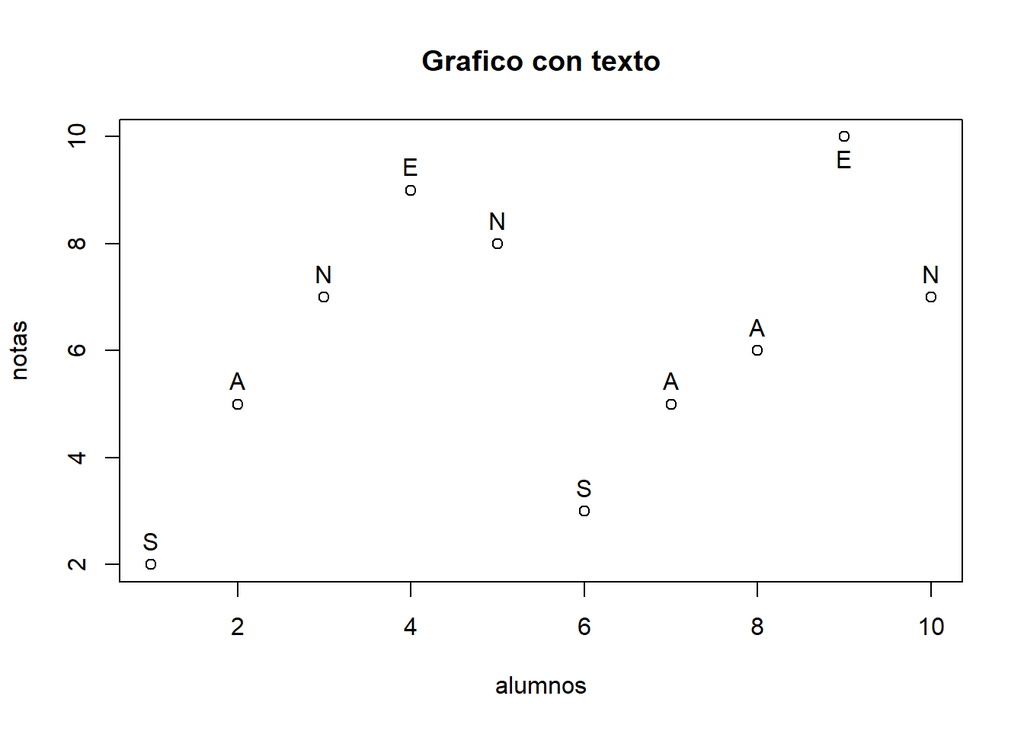

```r
alumnos = c(1:10)
notas = c(2,5,7,9,8,3,5,6,10,7)
plot(alumnos, notas, main = "Grafico con texto")
text(alumnos, notas, labels = c("S","A","N","E","N","S","A","A","E","N"), pos=c(rep(3,times = 8),1,3))
```

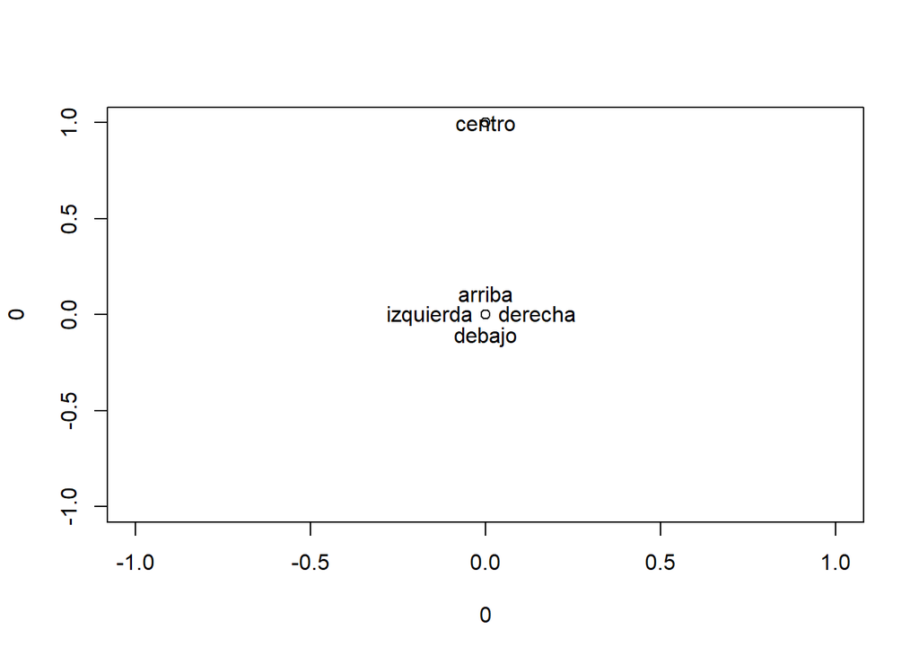

```r
plot(0,0)
text(0,0, labels = "debajo", pos = 1)
text(0,0, labels = "izquierda", pos = 2)
text(0,0, labels = "arriba", pos = 3)
text(0,0, labels = "derecha", pos = 4)
points(0,1)
text(0,1, labels = "centro")
```

Añadir elementos al gráfico  
-lines(x,y): añade a un gráfico existente una línea poligonal que une los puntos (xi,yi) sucesivos. x, y son vectores numéricos  
-curve(curva): permite añadir la gráfica de una curva a un gráfico existente  
- add=TRUE: si no, la curva no se añade  
- La curva se puede especificar mediante una expresión algebraica con variable x, o mediante su nombre si la hemos definido antes.